# Análisis Predictivo en Business Intelligence: clasificación en Python

- Mostrar todo el código
- Ocultar todo el código
- Ver el código fuente

Autor/a

Fernando Salcedo Mejía Eco, Ms

Fecha de publicación

1 de febrero de 2026

Este notebook desarrolla en Python el caso de clasificación de la presentación **Análisis Predictivo en Business Intelligence**. En este notebook usamos cuatro librerías:

| Librería | Funciones | Para qué sirve |
| --- | --- | --- |
| `statsmodels` | `smf.logit()` | Estimar la regresión logística y ver sus coeficientes y valores p |
| `scikit-learn` | `DecisionTreeClassifier()`, `RandomForestClassifier()` | Estimar el árbol de clasificación y el random forest |
| `xgboost` | `XGBClassifier()` | Estimar XGBoost |
| `scikit-learn` | `accuracy_score()`, `roc_auc_score()`, `ConfusionMatrixDisplay`, … | Evaluar las predicciones |

**Código**

```python
import matplotlib.pyplot as plt
import numpy as np
import pandas as pd
import seaborn as sns
import statsmodels.formula.api as smf
from sklearn.ensemble import RandomForestClassifier
from sklearn.metrics import (
    ConfusionMatrixDisplay,
    RocCurveDisplay,
    accuracy_score,
    f1_score,
    precision_score,
    recall_score,
    roc_auc_score,
)
from sklearn.model_selection import train_test_split
from sklearn.tree import DecisionTreeClassifier, export_text, plot_tree
from xgboost import XGBClassifier, plot_importance

sns.set_theme(style="whitegrid", font_scale=1.1)
pd.set_option("display.precision", 3)  # mostrar los resultados con 3 decimales
```

# 1 Fuga de clientes (churn)

Una empresa de telecomunicaciones quiere decidir **a qué clientes dirigir una campaña de retención**. Se comparan cuatro modelos de clasificación: logit, árbol de clasificación, random forest y XGBoost.

## 1.1 Datos

Los datos disponibles describen a 5.000 clientes de la empresa. Cada fila es un cliente y las columnas son:

| Variable | Tipo | Descripción | Valores |
| --- | --- | --- | --- |
| `id_cliente` | Identificador | Número único del cliente | 1 a 5.000 |
| `antiguedad` | Numérica | Meses que lleva el cliente con la empresa | 1 a 72 meses |
| `cargo_mensual` | Numérica | Valor que paga el cliente cada mes (USD) | 20 a 150 USD |
| `contrato` | Categórica | Tipo de contrato | Mensual, Anual, Bianual |
| `llamadas_soporte` | Numérica (conteo) | Número de llamadas del cliente al servicio de soporte | 0, 1, 2, … |
| `pago_electronico` | Binaria | Si el cliente paga con medio electrónico | 1 = sí, 0 = no |
| `churn` | Binaria (**respuesta**) | Si el cliente abandonó la empresa | 1 = Fuga, 0 = Permanece |
| `conjunto` | Identificador | Partición asignada al cliente | entrenamiento, prueba |

`churn` es la variable que se quiere predecir; las cinco variables de antigüedad, cargo, contrato, llamadas y forma de pago son los **predictores**. En Python `churn` se deja como número: 1 = Fuga y 0 = Permanece. `contrato` se convierte en una variable categórica con `Mensual` como primera categoría, para que sea la categoría de referencia del logit.

**Código**

```python
telco = pd.read_csv("datos/telco_churn.csv")

telco["contrato"] = pd.Categorical(
    telco["contrato"], categories=["Mensual", "Anual", "Bianual"]
)

telco.head()
```

|  | id_cliente | antiguedad | cargo_mensual | contrato | llamadas_soporte | pago_electronico | churn | conjunto |
| --- | --- | --- | --- | --- | --- | --- | --- | --- |
| 0 | 1 | 38 | 52.2 | Bianual | 1 | 0 | 0 | entrenamiento |
| 1 | 2 | 45 | 119.3 | Anual | 2 | 0 | 0 | entrenamiento |
| 2 | 3 | 36 | 98.6 | Mensual | 1 | 1 | 1 | entrenamiento |
| 3 | 4 | 48 | 59.7 | Bianual | 3 | 0 | 0 | entrenamiento |
| 4 | 5 | 5 | 50.0 | Anual | 3 | 0 | 0 | entrenamiento |

## 1.2 Análisis exploratorio

**Código**

```python
tasa_general = telco["churn"].mean()
```

La tasa de fuga general es de 20.8 %: aproximadamente uno de cada cinco clientes abandona la empresa. El análisis exploratorio busca qué diferencia a los clientes que se van de los que permanecen.

### 1.2.1 Variables numéricas

Se compara la distribución de la antigüedad y del cargo mensual entre los clientes que se van y los que permanecen:

**Código**

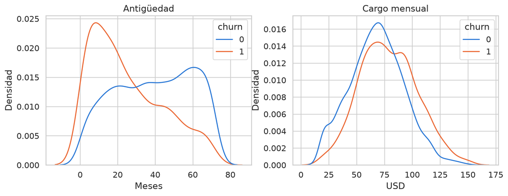

```python
colores_churn = {0: "#2a78d6", 1: "#eb6834"}

fig, axes = plt.subplots(1, 2, figsize=(12, 4))

sns.kdeplot(
    data=telco,
    x="antiguedad",
    hue="churn",
    palette=colores_churn,
    common_norm=False,
    ax=axes[0],
)
axes[0].set(title="Antigüedad", xlabel="Meses", ylabel="Densidad")

sns.kdeplot(
    data=telco,
    x="cargo_mensual",
    hue="churn",
    palette=colores_churn,
    common_norm=False,
    ax=axes[1],
)
axes[1].set(title="Cargo mensual", xlabel="USD", ylabel="Densidad")

plt.show()
```

En los gráficos, `churn = 1` (naranja) son los clientes que se fugan. Los clientes que se fugan se concentran en los **primeros meses** de relación con la empresa, mientras que los que permanecen tienen antigüedades mayores. En el cargo mensual la diferencia es menor, pero los clientes que se van tienden a pagar **cargos más altos**.

### 1.2.2 Variables categóricas

Para las variables con pocas categorías se calcula la tasa de fuga de cada categoría. Como `churn` vale 1 cuando el cliente se fuga, **el promedio de `churn` es la tasa de fuga**. La línea punteada es la tasa de fuga general. Las llamadas a soporte se agrupan en “4 o más” porque hay pocos clientes con más llamadas.

**Código**

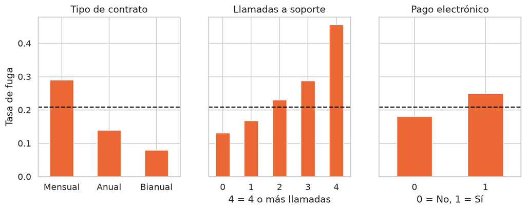

```python
telco["llamadas"] = telco["llamadas_soporte"].clip(upper=4)

fig, axes = plt.subplots(1, 3, figsize=(12, 4), sharey=True)

telco.groupby("contrato", observed=True)["churn"].mean().plot.bar(
    ax=axes[0], color="#eb6834"
)
axes[0].set(title="Tipo de contrato", xlabel="", ylabel="Tasa de fuga")

telco.groupby("llamadas")["churn"].mean().plot.bar(ax=axes[1], color="#eb6834")
axes[1].set(title="Llamadas a soporte", xlabel="4 = 4 o más llamadas")

telco.groupby("pago_electronico")["churn"].mean().plot.bar(ax=axes[2], color="#eb6834")
axes[2].set(title="Pago electrónico", xlabel="0 = No, 1 = Sí")

for ax in axes:
    ax.axhline(tasa_general, color="black", linestyle="--")
    ax.tick_params(axis="x", rotation=0)

plt.show()
```

- **Contrato:** los clientes con contrato mensual se van mucho más que los de contratos largos; el contrato bianual tiene la tasa de fuga más baja.
- **Llamadas a soporte:** la tasa de fuga crece con cada llamada adicional. Un cliente que llama mucho a soporte es un cliente insatisfecho.
- **Pago electrónico:** los clientes que pagan con medio electrónico se fugan algo más que los demás.

### 1.2.3 Interacción entre antigüedad y cargo mensual

Las variables también pueden actuar en conjunto. El mapa de calor muestra la tasa de fuga para cada combinación de tramos de antigüedad y de cargo mensual. Un tramo como `(0, 12]` significa “más de 0 y hasta 12”.

**Código**

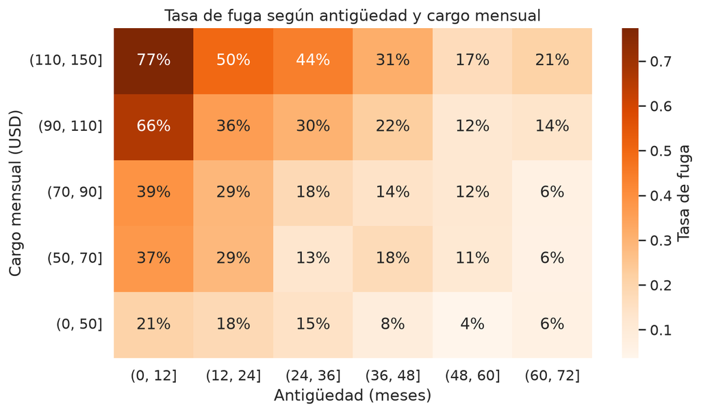

```python
telco["tramo_antiguedad"] = pd.cut(
    telco["antiguedad"], bins=[0, 12, 24, 36, 48, 60, 72]
)
telco["tramo_cargo"] = pd.cut(telco["cargo_mensual"], bins=[0, 50, 70, 90, 110, 150])

tasas = telco.pivot_table(
    index="tramo_cargo",
    columns="tramo_antiguedad",
    values="churn",
    aggfunc="mean",
    observed=True,
)

plt.figure(figsize=(9, 5))
sns.heatmap(
    tasas, annot=True, fmt=".0%", cmap="Oranges", cbar_kws={"label": "Tasa de fuga"}
)
plt.gca().invert_yaxis()  # cargos más altos arriba
plt.title("Tasa de fuga según antigüedad y cargo mensual")
plt.xlabel("Antigüedad (meses)")
plt.ylabel("Cargo mensual (USD)")
plt.show()
```

La fuga es máxima en la esquina superior izquierda: **clientes nuevos (menos de un año) con cargos altos (más de 90 USD)**, donde se van dos de cada tres clientes o más. Este tipo de combinación es difícil de capturar con un logit que solo incluye cada variable por separado, pero los árboles, el random forest y XGBoost la pueden detectar por sí mismos.

## 1.3 Entrenamiento y prueba

Los datos se dividen con `train_test_split()` de scikit-learn: 70 % de los clientes para entrenar y 30 % para evaluar (`test_size=0.3`). Con `stratify=telco["churn"]` la partición es **estratificada**, es decir, ambos conjuntos conservan la misma proporción de clientes que se fugan. `random_state=2026` fija la semilla aleatoria para que la partición sea siempre la misma.

No hace falta eliminar `id_cliente` ni `conjunto`, porque en este notebook los predictores de cada modelo se indican explícitamente.

**Código**

```python
entrenamiento, prueba = train_test_split(
    telco, test_size=0.3, stratify=telco["churn"], random_state=2026
)

pd.DataFrame(
    {
        "clientes": [len(entrenamiento), len(prueba)],
        "tasa_fuga": [entrenamiento["churn"].mean(), prueba["churn"].mean()],
    },
    index=["Entrenamiento", "Prueba"],
)
```

|  | clientes | tasa_fuga |
| --- | --- | --- |
| Entrenamiento | 3500 | 0.208 |
| Prueba | 1500 | 0.209 |

## 1.4 Regresión logística (logit)

El logit se estima con `smf.logit()` de statsmodels, usando una fórmula: la variable de respuesta a la izquierda de `~` y los predictores a la derecha.

**Código**

```python
formula = "churn ~ antiguedad + cargo_mensual + contrato + llamadas_soporte + pago_electronico"

logit = smf.logit(formula, data=entrenamiento).fit(disp=False)
logit.summary()
```

Logit Regression Results

| Dep. Variable: | churn | No. Observations: | 3500 |
| --- | --- | --- | --- |
| Model: | Logit | Df Residuals: | 3493 |
| Method: | MLE | Df Model: | 6 |
| Date: | Tue, 17 Nov 2026 | Pseudo R-squ.: | 0.2263 |
| Time: | 23:22:52 | Log-Likelihood: | -1385.7 |
| converged: | True | LL-Null: | -1790.9 |
| Covariance Type: | nonrobust | LLR p-value: | 8.578e-172 |

|  | coef | std err | z | P>\|z\| | [0.025 | 0.975] |
| --- | --- | --- | --- | --- | --- | --- |
| Intercept | -2.0502 | 0.185 | -11.090 | 0.000 | -2.413 | -1.688 |
| contrato[T.Anual] | -1.1379 | 0.121 | -9.416 | 0.000 | -1.375 | -0.901 |
| contrato[T.Bianual] | -1.8609 | 0.160 | -11.616 | 0.000 | -2.175 | -1.547 |
| antiguedad | -0.0442 | 0.003 | -17.207 | 0.000 | -0.049 | -0.039 |
| cargo_mensual | 0.0228 | 0.002 | 11.466 | 0.000 | 0.019 | 0.027 |
| llamadas_soporte | 0.4556 | 0.039 | 11.643 | 0.000 | 0.379 | 0.532 |
| pago_electronico | 0.5462 | 0.096 | 5.670 | 0.000 | 0.357 | 0.735 |

Los **odds ratios** ($e^{\beta_j}$) facilitan la interpretación. Se calculan aplicando `np.exp()` a los coeficientes y a sus intervalos de confianza:

**Código**

```python
odds_ratios = pd.DataFrame(
    {
        "odds_ratio": np.exp(logit.params),
        "conf.low": np.exp(logit.conf_int()[0]),
        "conf.high": np.exp(logit.conf_int()[1]),
        "p.value": logit.pvalues,
    }
)
odds_ratios
```

|  | odds_ratio | conf.low | conf.high | p.value |
| --- | --- | --- | --- | --- |
| Intercept | 0.129 | 0.090 | 0.185 | 1.404e-28 |
| contrato[T.Anual] | 0.320 | 0.253 | 0.406 | 4.670e-21 |
| contrato[T.Bianual] | 0.156 | 0.114 | 0.213 | 3.435e-31 |
| antiguedad | 0.957 | 0.952 | 0.962 | 2.360e-66 |
| cargo_mensual | 1.023 | 1.019 | 1.027 | 1.945e-30 |
| llamadas_soporte | 1.577 | 1.461 | 1.703 | 2.483e-31 |
| pago_electronico | 1.727 | 1.430 | 2.085 | 1.428e-08 |

Cada llamada adicional a soporte multiplica los *odds* de fuga por 1.58, mientras que un contrato bianual los multiplica por 0.16 frente al contrato mensual.

## 1.5 Predictores para scikit-learn y XGBoost

scikit-learn y XGBoost no usan fórmulas: necesitan una tabla de predictores **numéricos** (`X`) y la variable de respuesta (`y`) por separado. `pd.get_dummies()` convierte `contrato` en variables indicadoras (0/1); con `drop_first=True` se elimina la de `Mensual`, que queda como categoría de referencia, igual que en el logit.

**Código**

```python
predictores = [
    "antiguedad",
    "cargo_mensual",
    "contrato",
    "llamadas_soporte",
    "pago_electronico",
]

X_entrenamiento = pd.get_dummies(entrenamiento[predictores], drop_first=True, dtype=int)
X_prueba = pd.get_dummies(prueba[predictores], drop_first=True, dtype=int)
y_entrenamiento = entrenamiento["churn"]
y_prueba = prueba["churn"]

X_entrenamiento.head()
```

|  | antiguedad | cargo_mensual | llamadas_soporte | pago_electronico | contrato_Anual | contrato_Bianual |
| --- | --- | --- | --- | --- | --- | --- |
| 191 | 9 | 52.8 | 4 | 0 | 0 | 0 |
| 3679 | 52 | 37.1 | 2 | 0 | 0 | 0 |
| 290 | 66 | 61.4 | 4 | 0 | 0 | 0 |
| 4795 | 49 | 70.1 | 2 | 1 | 0 | 1 |
| 2782 | 67 | 20.0 | 0 | 1 | 0 | 0 |

## 1.6 Árbol de clasificación

Para evitar el sobreajuste se limita el crecimiento del árbol:

- `max_depth=3`: máximo 3 niveles de preguntas.
- `min_samples_split=150`: un nodo necesita al menos 150 clientes para dividirse.
- `min_samples_leaf=50`: cada hoja debe tener al menos 50 clientes.

**Código**

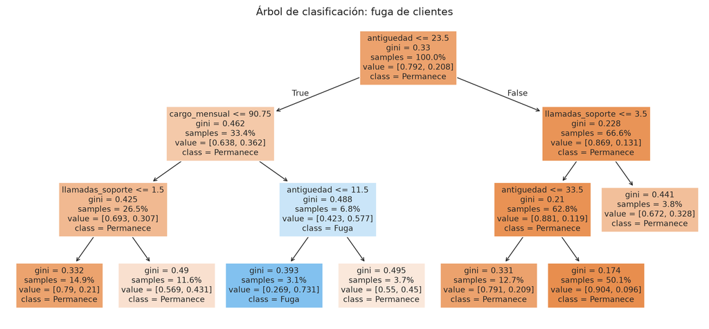

```python
arbol = DecisionTreeClassifier(
    max_depth=3, min_samples_split=150, min_samples_leaf=50, random_state=2026
)
arbol.fit(X_entrenamiento, y_entrenamiento)

plt.figure(figsize=(16, 7))
plot_tree(
    arbol,
    feature_names=X_entrenamiento.columns,
    class_names=["Permanece", "Fuga"],
    filled=True,
    proportion=True,
    fontsize=10,
)
plt.title("Árbol de clasificación: fuga de clientes")
plt.show()
```

El árbol también puede expresarse como **reglas de decisión** para comunicarlas a la gerencia. Con `show_weights=True` cada hoja muestra la proporción de clientes que permanecen y que se fugan:

**Código**

```python
print(
    export_text(arbol, feature_names=list(X_entrenamiento.columns), show_weights=True)
)
```

```
|--- antiguedad <= 23.50
|   |--- cargo_mensual <= 90.75
|   |   |--- llamadas_soporte <= 1.50
|   |   |   |--- weights: [413.00, 110.00] class: 0
|   |   |--- llamadas_soporte >  1.50
|   |   |   |--- weights: [231.00, 175.00] class: 0
|   |--- cargo_mensual >  90.75
|   |   |--- antiguedad <= 11.50
|   |   |   |--- weights: [29.00, 79.00] class: 1
|   |   |--- antiguedad >  11.50
|   |   |   |--- weights: [72.00, 59.00] class: 0
|--- antiguedad >  23.50
|   |--- llamadas_soporte <= 3.50
|   |   |--- antiguedad <= 33.50
|   |   |   |--- weights: [351.00, 93.00] class: 0
|   |   |--- antiguedad >  33.50
|   |   |   |--- weights: [1585.00, 169.00] class: 0
|   |--- llamadas_soporte >  3.50
|   |   |--- weights: [90.00, 44.00] class: 0
```

## 1.7 Random forest

Se usan 300 árboles (`n_estimators=300`), y cada hoja debe tener al menos 20 clientes (`min_samples_leaf=20`).

**Código**

```python
bosque = RandomForestClassifier(
    n_estimators=300, min_samples_leaf=20, random_state=2026
)
bosque.fit(X_entrenamiento, y_entrenamiento)
```

```
RandomForestClassifier(min_samples_leaf=20, n_estimators=300, random_state=2026)
```

La importancia de las variables mide cuánto contribuye cada una a reducir la impureza (Gini) de los árboles:

**Código**

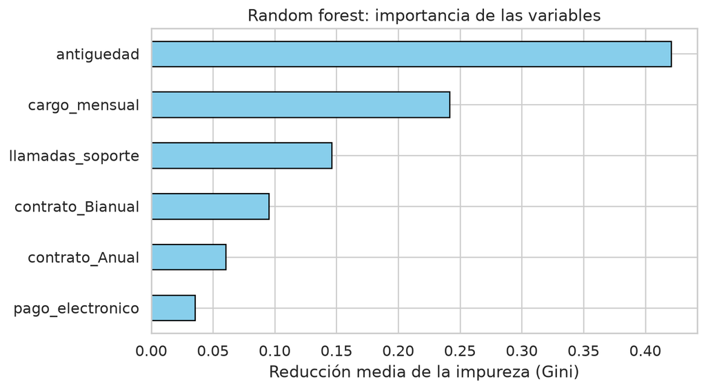

```python
importancia = pd.Series(bosque.feature_importances_, index=X_entrenamiento.columns)

importancia.sort_values().plot.barh(
    color="skyblue", edgecolor="black", figsize=(8, 4.5)
)
plt.title("Random forest: importancia de las variables")
plt.xlabel("Reducción media de la impureza (Gini)")
plt.show()
```

## 1.8 XGBoost

El random forest construye muchos árboles **en paralelo** e independientes, y promedia sus votos. **XGBoost** (*extreme gradient boosting*) también combina muchos árboles, pero los construye **en secuencia**: cada árbol nuevo se ajusta a los errores que dejaron los anteriores, y su aporte se suma al modelo multiplicado por una **tasa de aprendizaje** pequeña, para que el modelo avance poco a poco y no se sobreajuste.

| Hiperparámetro | Valor | Qué controla |
| --- | --- | --- |
| `n_estimators` | 300 | Número de árboles en la secuencia |
| `max_depth` | 3 | Profundidad de cada árbol (árboles pequeños, “débiles”) |
| `learning_rate` | 0.05 | Cuánto aporta cada árbol nuevo al modelo |
| `min_child_weight` | 20 | Controla el tamaño mínimo de cada hoja |

**Código**

```python
xgb = XGBClassifier(
    n_estimators=300,
    max_depth=3,
    learning_rate=0.05,
    min_child_weight=20,
    random_state=2026,
)
xgb.fit(X_entrenamiento, y_entrenamiento)
```

```
XGBClassifier(base_score=None, booster=None, callbacks=None,
              colsample_bylevel=None, colsample_bynode=None,
              colsample_bytree=None, device=None, early_stopping_rounds=None,
              enable_categorical=False, eval_metric=None, feature_types=None,
              feature_weights=None, gamma=None, grow_policy=None,
              importance_type=None, interaction_constraints=None,
              learning_rate=0.05, max_bin=None, max_cat_threshold=None,
              max_cat_to_onehot=None, max_delta_step=None, max_depth=3,
              max_leaves=None, min_child_weight=20, missing=nan,
              monotone_constraints=None, multi_strategy=None, n_estimators=300,
              n_jobs=None, num_parallel_tree=None, ...)
```

La importancia de cada variable en XGBoost se mide con la **ganancia** (*gain*): cuánto mejora el ajuste, en promedio, cada vez que un árbol usa esa variable para dividir.

**Código**

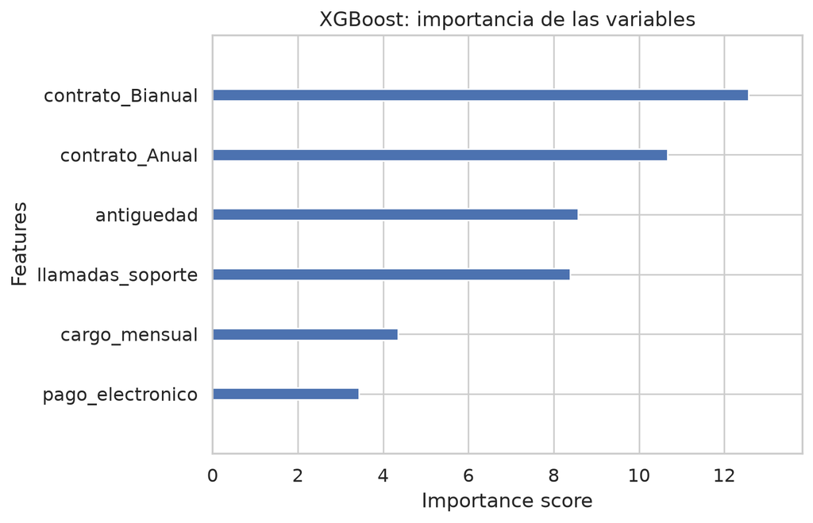

```python
plot_importance(
    xgb,
    importance_type="gain",
    show_values=False,
    title="XGBoost: importancia de las variables",
)
plt.show()
```

## 1.9 Comparación de modelos

Cada modelo calcula la **probabilidad de fuga** de los clientes de prueba:

- En statsmodels, `logit.predict()` entrega directamente la probabilidad de fuga.
- En scikit-learn y XGBoost, `predict_proba()` entrega una columna por clase; la segunda (`[:, 1]`) es la probabilidad de `churn = 1`, es decir, de fuga.

Se guardan las probabilidades de los cuatro modelos en un diccionario:

**Código**

```python
probabilidades = {
    "Logit": logit.predict(prueba),
    "Árbol": arbol.predict_proba(X_prueba)[:, 1],
    "Random forest": bosque.predict_proba(X_prueba)[:, 1],
    "XGBoost": xgb.predict_proba(X_prueba)[:, 1],
}
```

Para cada modelo se predice fuga cuando la probabilidad es mayor o igual a 0.5, y se calculan las métricas. La especificidad no tiene una función propia en scikit-learn: es la sensibilidad (`recall_score`) de la clase 0, por eso se calcula con `pos_label=0`.

| Función de scikit-learn | Métrica |
| --- | --- |
| `accuracy_score` | Exactitud |
| `precision_score` | Precisión |
| `recall_score` | Sensibilidad |
| `recall_score(..., pos_label=0)` | Especificidad |
| `f1_score` | F1 |
| `roc_auc_score` | AUC |

**Código**

```python
filas = []
for modelo, prob in probabilidades.items():
    clase = (prob >= 0.5).astype(int)
    filas.append(
        {
            "modelo": modelo,
            "exactitud": accuracy_score(y_prueba, clase),
            "precisión": precision_score(y_prueba, clase),
            "sensibilidad": recall_score(y_prueba, clase),
            "especificidad": recall_score(y_prueba, clase, pos_label=0),
            "F1": f1_score(y_prueba, clase),
            "AUC": roc_auc_score(y_prueba, prob),
        }
    )

metricas = pd.DataFrame(filas).set_index("modelo")
metricas
```

| modelo | exactitud | precisión | sensibilidad | especificidad | F1 | AUC |
| --- | --- | --- | --- | --- | --- | --- |
| Logit | 0.819 | 0.615 | 0.351 | 0.942 | 0.447 | 0.799 |
| Árbol | 0.803 | 0.707 | 0.093 | 0.990 | 0.164 | 0.679 |
| Random forest | 0.815 | 0.650 | 0.243 | 0.965 | 0.353 | 0.782 |
| XGBoost | 0.812 | 0.579 | 0.361 | 0.931 | 0.445 | 0.790 |

El **logit**, **XGBoost** y el **random forest** obtienen un AUC muy parecido (alrededor de 0.80), claramente por encima del árbol. Un modelo más complejo no siempre predice mejor: cuando la relación entre las variables y el *log-odds* de fuga es casi lineal, un modelo simple como el logit compite de igual a igual con los modelos más complejos. Como además es más fácil de interpretar, en lo que sigue se trabaja con el logit. Con el umbral de 0.5 la **sensibilidad es baja** (se detecta una minoría de los clientes que se van), lo que motiva revisar el umbral.

## 1.10 Matriz de confusión y curva ROC

Matriz de confusión del logit con el umbral de 0.5:

**Código**

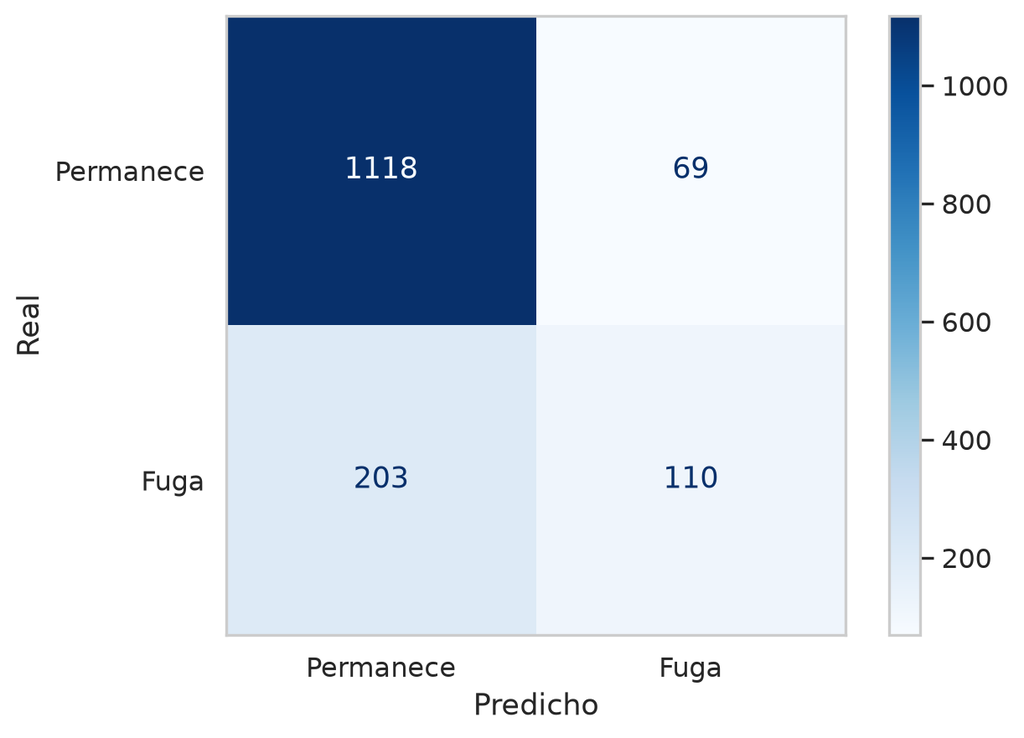

```python
prob_logit = probabilidades["Logit"]

ConfusionMatrixDisplay.from_predictions(
    y_prueba,
    (prob_logit >= 0.5).astype(int),
    display_labels=["Permanece", "Fuga"],
    cmap="Blues",
)
plt.xlabel("Predicho")
plt.ylabel("Real")
plt.grid(False)
plt.show()
```

Curva ROC de los cuatro modelos:

**Código**

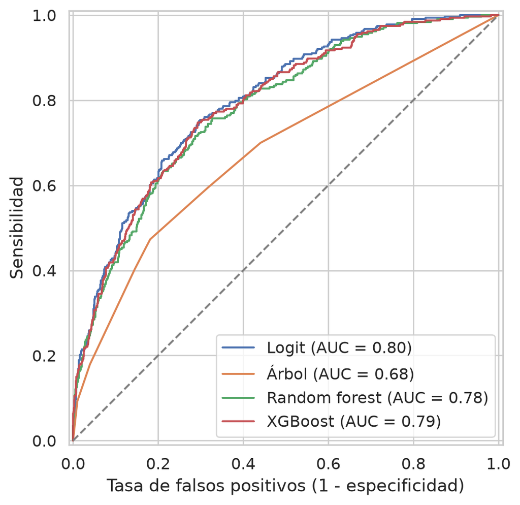

```python
fig, ax = plt.subplots(figsize=(7, 6))

for modelo, prob in probabilidades.items():
    RocCurveDisplay.from_predictions(y_prueba, prob, name=modelo, ax=ax)

ax.plot([0, 1], [0, 1], color="gray", linestyle="--")
ax.set(xlabel="Tasa de falsos positivos (1 - especificidad)", ylabel="Sensibilidad")
plt.show()
```

## 1.11 Elegir el umbral

Los modelos anteriores predicen que un cliente se fuga cuando su probabilidad de fuga es **mayor o igual a 0.5**. Ese umbral es una convención estadística, no una decisión de negocio.

Supongamos que una campaña de retención tiene los siguientes valores:

- Contactar a un cliente cuesta **USD 20**.
- Retener a un cliente que se iba a fugar vale **USD 100**.

Si se contacta a un cliente que no se iba a ir (**falso positivo**), se pierden USD 20. Si no se contacta a un cliente que sí se iba (**falso negativo**), se pierden USD 100. Dejar escapar a un cliente cuesta **cinco veces más** que contactarlo de más.

Por eso conviene contactar también a clientes con probabilidad de fuga menor a 0.5. Por ejemplo, contactar a un cliente con probabilidad de fuga de 0.3 deja en promedio $0.3 \times 100 - 20 = 10$ USD de beneficio.

Para un umbral $u$, se contacta a todos los clientes con probabilidad de fuga mayor o igual a $u$, y el beneficio de la campaña es:

$$\text{Beneficio}(u) = 100 \cdot VP(u) - 20 \cdot \left[VP(u) + FP(u)\right]$$

donde $VP(u)$ son los clientes contactados que sí se iban a fugar y $VP(u) + FP(u)$ es el total de clientes contactados. El objetivo es encontrar el umbral que **maximiza el beneficio**.

Para cada umbral posible se calcula a cuántos clientes se contactaría y cuántos de ellos realmente se iban a fugar (verdaderos positivos):

**Código**

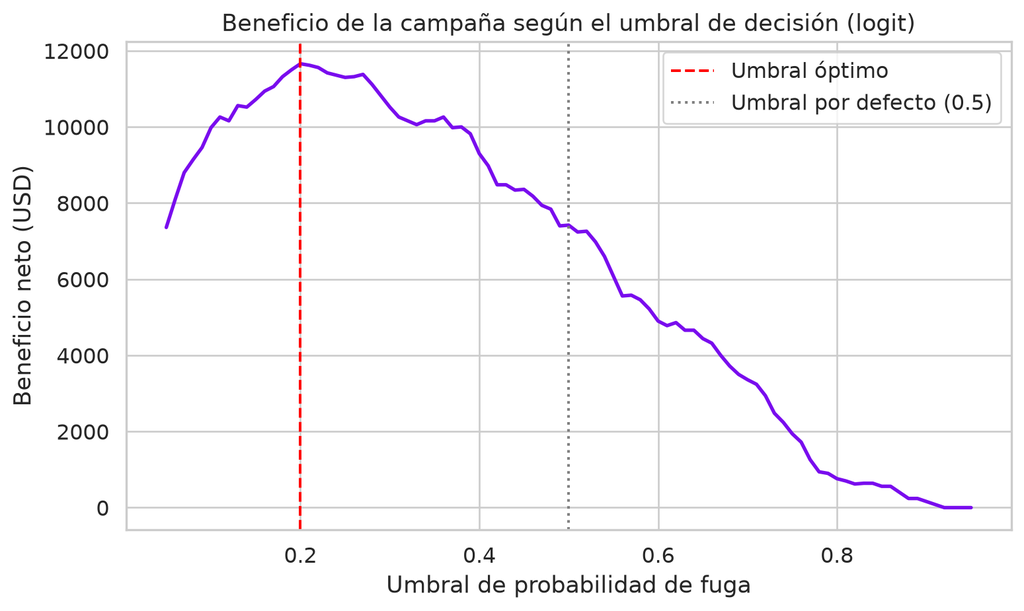

```python
umbrales = np.round(np.arange(0.05, 0.96, 0.01), 2)
beneficio = []

for u in umbrales:
    contactados = prob_logit >= u
    vp = (contactados & (y_prueba == 1)).sum()
    beneficio.append(100 * vp - 20 * contactados.sum())

beneficio = np.array(beneficio)
umbral_optimo = umbrales[beneficio.argmax()]
beneficio_05 = beneficio[umbrales == 0.5][0]

plt.figure(figsize=(9, 5))
plt.plot(umbrales, beneficio, color="#790cee", linewidth=2)
plt.axvline(umbral_optimo, color="red", linestyle="--", label="Umbral óptimo")
plt.axvline(0.5, color="gray", linestyle=":", label="Umbral por defecto (0.5)")
plt.title("Beneficio de la campaña según el umbral de decisión (logit)")
plt.xlabel("Umbral de probabilidad de fuga")
plt.ylabel("Beneficio neto (USD)")
plt.legend()
plt.show()
```

Con el umbral por defecto de 0.5 la campaña genera USD 7.420. Con el umbral óptimo de 0.20 el beneficio sube a USD 11.660. Como retener a un cliente vale cinco veces lo que cuesta contactarlo, conviene contactar a muchos más clientes de los que el umbral de 0.5 sugiere.

Con el umbral óptimo, las métricas del modelo cambian: se sacrifica precisión a cambio de detectar a muchos más clientes que se van.

**Código**

```python
clase_05 = (prob_logit >= 0.5).astype(int)
clase_optima = (prob_logit >= umbral_optimo).astype(int)

pd.DataFrame(
    {
        "umbral 0.5": [
            accuracy_score(y_prueba, clase_05),
            precision_score(y_prueba, clase_05),
            recall_score(y_prueba, clase_05),
            recall_score(y_prueba, clase_05, pos_label=0),
        ],
        "umbral óptimo": [
            accuracy_score(y_prueba, clase_optima),
            precision_score(y_prueba, clase_optima),
            recall_score(y_prueba, clase_optima),
            recall_score(y_prueba, clase_optima, pos_label=0),
        ],
    },
    index=["exactitud", "precisión", "sensibilidad", "especificidad"],
)
```

|  | umbral 0.5 | umbral óptimo |
| --- | --- | --- |
| exactitud | 0.819 | 0.704 |
| precisión | 0.615 | 0.392 |
| sensibilidad | 0.351 | 0.760 |
| especificidad | 0.942 | 0.689 |